# market segmentation

Jason Signolet

Thursday, 28 May 2015

I’ve managed to get a decent-looking 4-cluster segmentation based on the opportunity scores from the Org questions. I’ve uploaded a file with the cluster assignments for the 4-cluster and a slightly different 3-cluster segmentation. I’ve provided a preliminary analysis, but the more detailed analysis is beyond my remit.

## Initialise the data

- I used the following libraries, and I changed all empty cells to NA

```r
library(ggplot2)
library(reshape)
library(Hmisc)

allData <- read.csv("sample-survey-data.csv", stringsAsFactors = F, row.names = 1)
allData[allData == ""] <- NA
```

- There were initially 183 responses. However, many of them did not fill in all of the fields.
- I used the following code to remove all respondents who left empty fields:

```r
sum(!is.na(rowSums(allData[,6:26], na.rm = F)))
```

```
## [1] 117
```

```r
cleanData <- allData[!is.na(rowSums(allData[,6:26], na.rm = F)), ]
```

- I split the data into four tables, one for each question type:

```r
details # Stuff like team size, number of clients, etc.
impPer  # important personally
impOrg  # important to the organisation
satis   # satisfaction
```

## Calculate opportunity scores

- I used these tables as matrices to calculate the opportunity score (OS) for the pers and org answers.
- This is basically a vectorised implementation of the equation, Opp = Imp + max(Imp - Sat, 0)

```r
oppPer <- impPer + ((impPer - satis) > 0) * (impPer - satis)
colnames(oppPer) <- paste("Q", seq(1,7), "_OP", sep = "")

oppOrg <- impOrg + ((impOrg - satis) > 0) * (impOrg - satis)
colnames(oppOrg) <- paste("Q", seq(1,7), "_OO", sep = "")
```

# Let’s deal with the “personal” answers first

## Dimensionality reduction using PCA

- I used the prcomp() function to perform a principal components analysis (pretty similar to the factor analysis). I added the first two components to the details table.
- From the biplot we can see that Q1-3 have similar loadings, and Q4-7 have similar loadings which are roughly orthogonal to Q1-3.

```r
modelPer <- prcomp(oppPer)

details$pc1Per <- predict(modelPer)[, 1]
details$pc2Per <- predict(modelPer)[, 2]
```

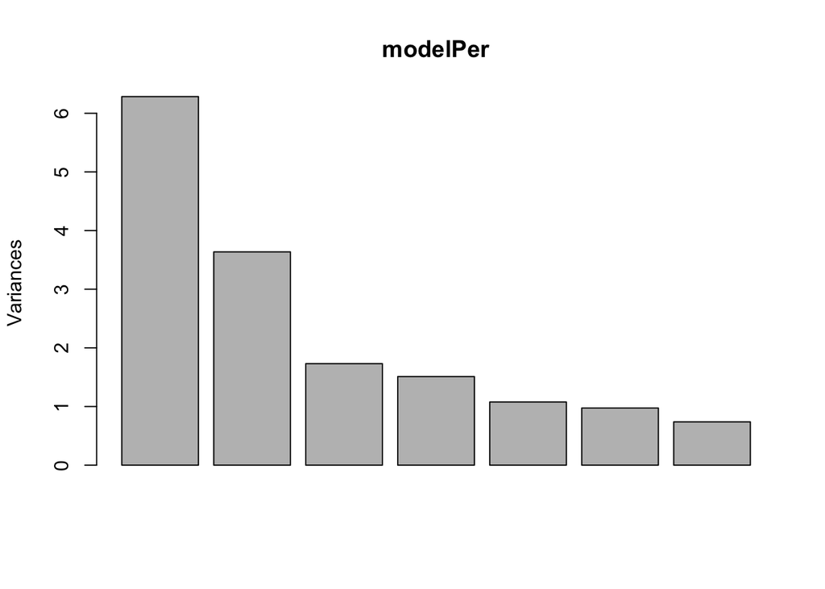

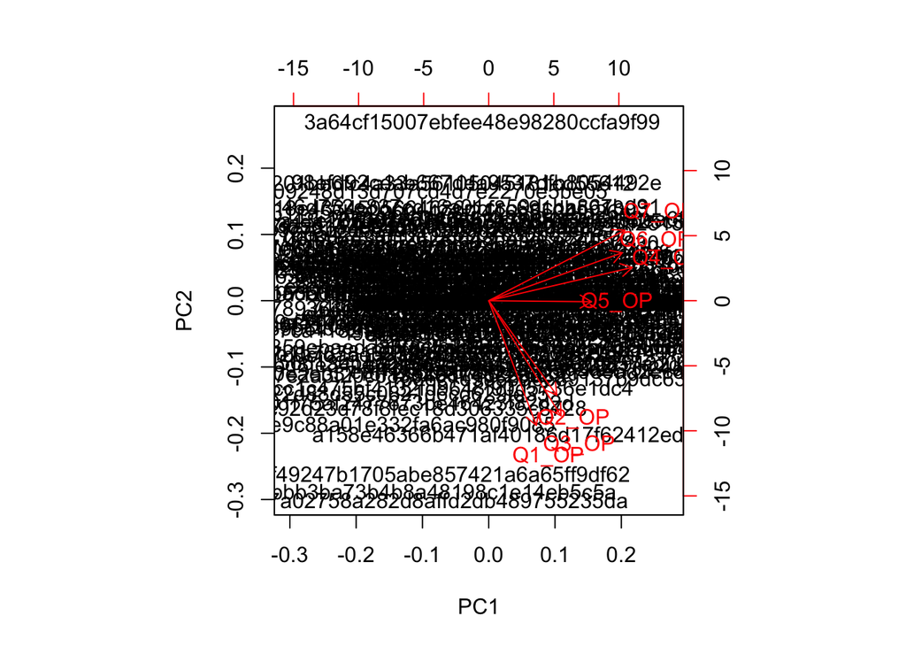

## Clustering

- I have used k-means clustering here as it is an easily accessible non-hierarchical clustering method.
- Firstly, you should determine number of clusters you will use. I’ve used the “bend in the elbow” method of plotting the within groups sum of squares (wss) against a number of clusters from 1 to 15.
- K-means clustering uses a random seed, so I repeated this calculation 100 times and took the average for each number of clusters (plot below).

```r
wss <- (nrow(details)-1)*sum(apply(details[, c("pc1Per", "pc2Per")],2,var))
wssAve <- as.data.frame(matrix(wss, 100, length(wss)))
for (i in 1:100){
  for (j in 2:15) wssAve[i, j] <- sum(kmeans(details[, c("pc1Per", "pc2Per")], centers=j)$withinss)
}
```

- The bend in the WSS plot suggests 3 or 4 clusters is optimal. I will use 3 clusters.

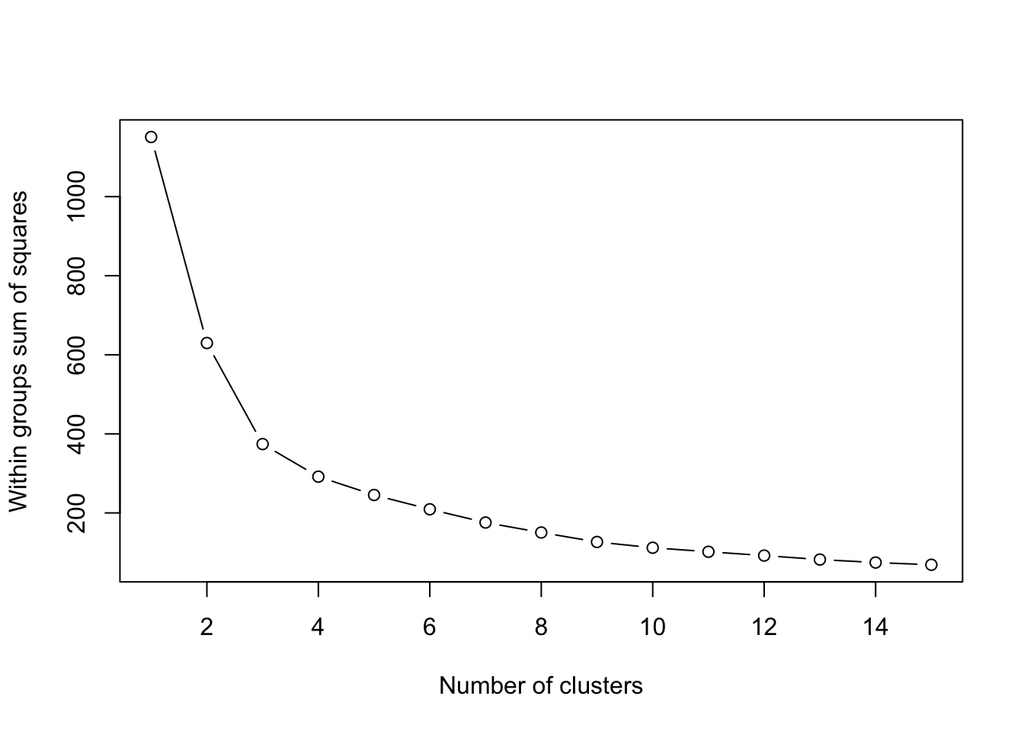

### K-Means Cluster Analysis

```r
set.seed(1)

fit <- kmeans(details[, c("pc1Per", "pc2Per")], 3)

# get cluster means
aggregate(details[, c("pc1Per", "pc2Per")],by=list(fit$cluster),FUN=mean)

# append cluster assignment
details$clusterPer <- fit$cluster
```

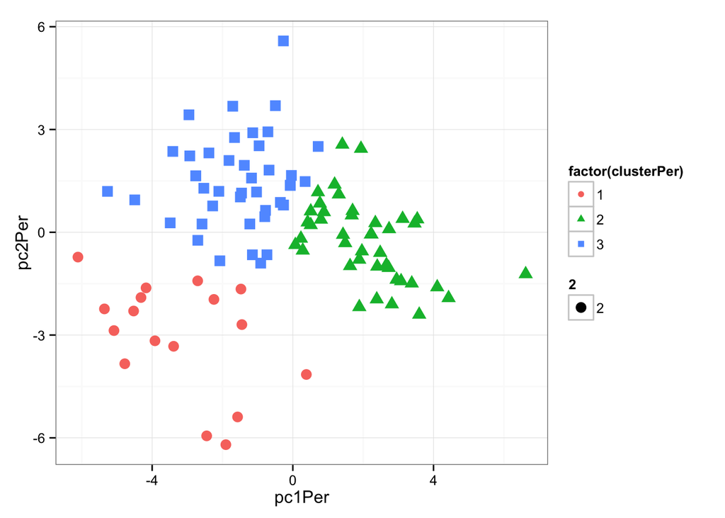

# Now let’s do the same with the Org answers

- Q1,2,3,5 have similar loadings, Q4,6,7 load roughly orthogonally to these.

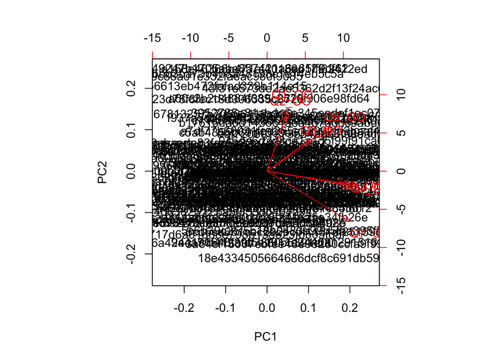

```r
modelOrg <- prcomp(oppOrg)
biplot(modelOrg)  ## As before, Q1-3 have similar loadings. Q4-7 have similar loadings.
```

```r
details$pc1Org <- predict(modelOrg)[, 1]
details$pc2Org <- predict(modelOrg)[, 2]

## Determine number of clusters
wss <- (nrow(details)-1)*sum(apply(details[, c("pc1Org", "pc2Org")],2,var))
wssAve <- as.data.frame(matrix(wss, 100, length(wss)))
for (i in 1:100){
  for (j in 2:15) wssAve[i, j] <- sum(kmeans(details[, c("pc1Org", "pc2Org")], centers=j)$withinss)
}
```

- The bend is around 4 this time.

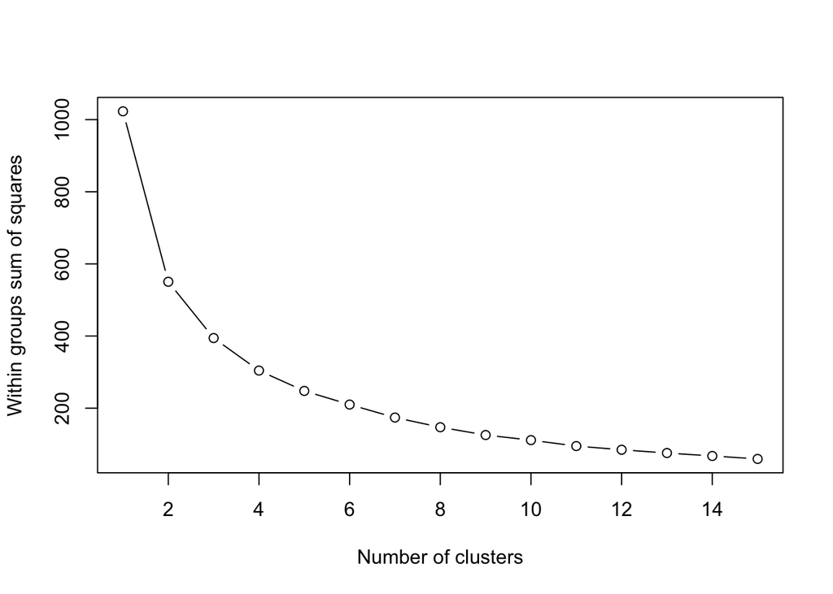

```r
## K-Means Cluster Analysis
set.seed(2)
fit <- kmeans(details[, c("pc1Org", "pc2Org")], 4)


# get cluster means
foo = aggregate(details[, c("pc1Org", "pc2Org")],by=list(fit$cluster),FUN=mean)
foo[order(foo[,2]),]

# append cluster assignment
details$clusterOrg <- fit$cluster
```

- The 4-cluster Org segmentation appears to give a fairly even split too, with 1 and 3 being larger

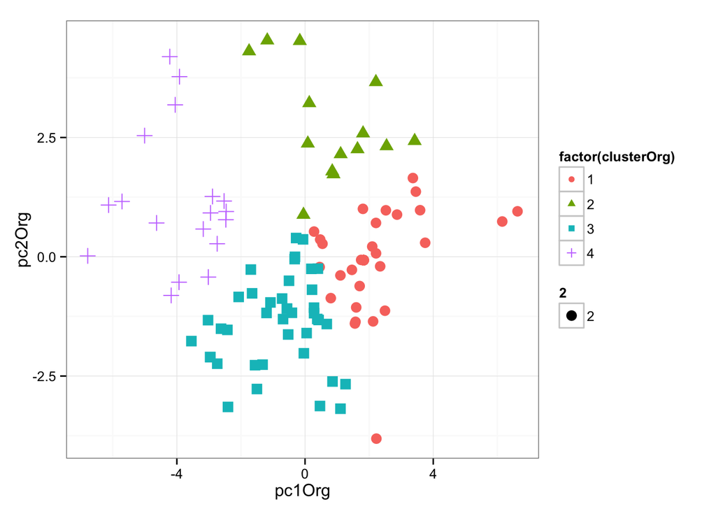

## Let’s see some detail

- First factorise the other answers so they come out in the right order

```r
details$Org.Size <- factor(details$Org.Size,
                           levels = levels(factor(details$Org.Size))[c(6, 3, 2, 5, 1, 4)])

details$Team.Size <- factor(details$Team.Size,
                           levels = levels(factor(details$Team.Size))[c(1, 3, 4, 2)])

details$Clients <- factor(details$Clients,
                           levels = levels(factor(details$Clients)))

details$Team.Manager <- factor(details$Team.Manager)

details$Consultant <- factor(details$Consultant)
```

- Using the 4-cluster Org system, what can we see?

```r
breakdown <- melt(details,
                  id.vars = "clusterOrg",
                  measure.vars = c("Org.Size", "Team.Size", "Clients", "Team.Manager","Consultant"))
```

- Cluster 1 respondents have the largest number of clients and are most likely to be managers and/or consultants.
- Cluster 3 respondents are like Cluster 1 respondents but are less likely to be managers or consultants and have fewer clients.
- Cluster 2 and 4 respondents work in small teams and small organisations, but cluster 4 includes solo ventures.

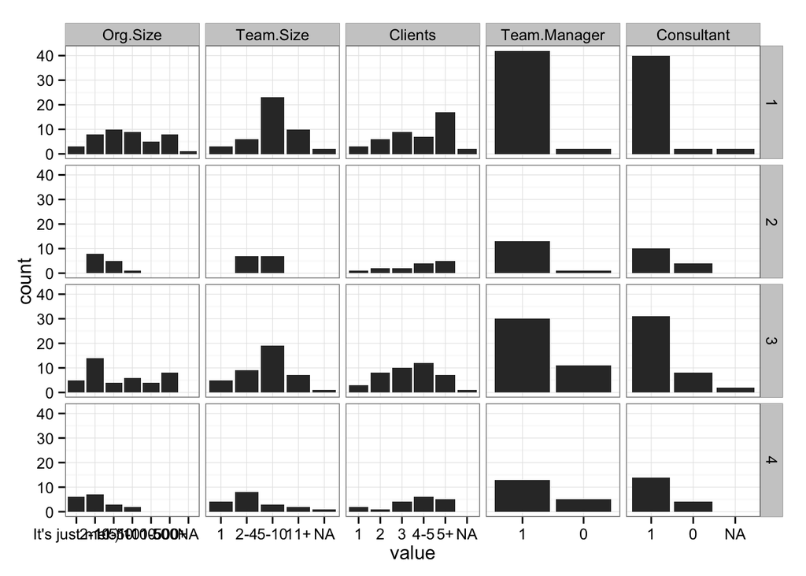

- Given that Q1,2,3,5 load orthogonally to Q4,6,7, let’s sum them.
- In the following plots, I have colour coded the Org-based plot using the summed OS data.

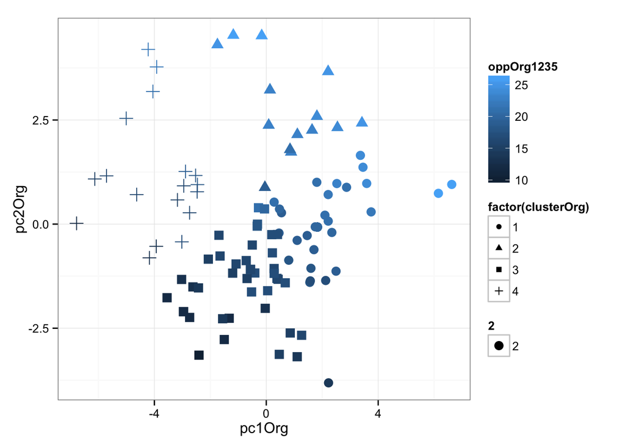

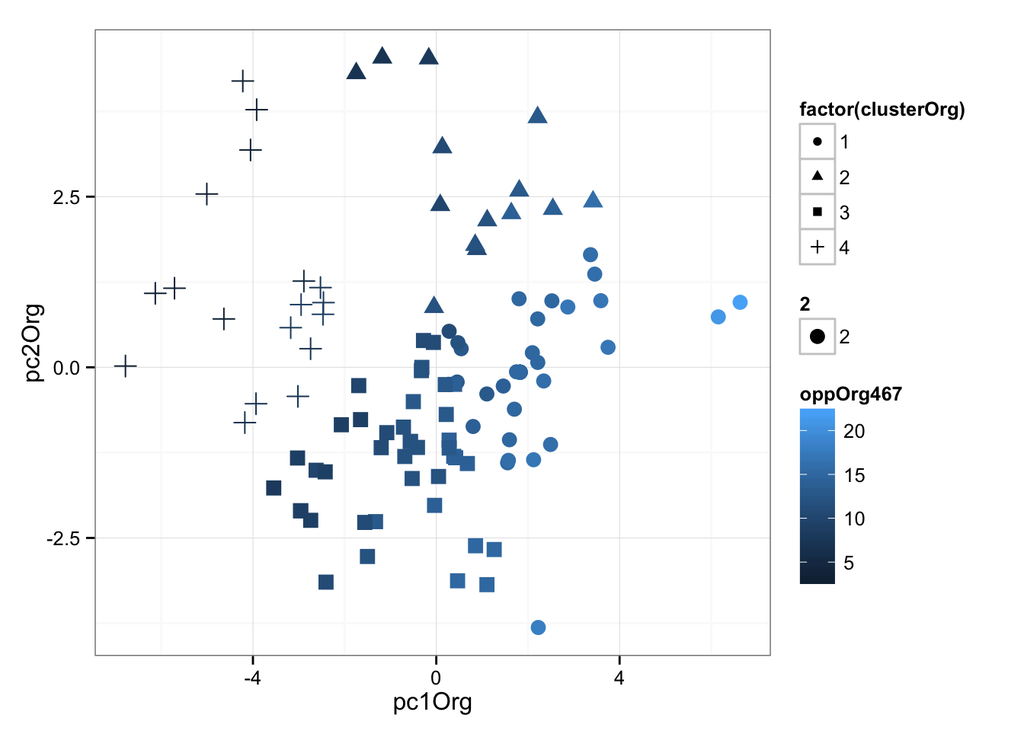

- Graph 1 let’s us see that the opportunity score for Q1235 is really low for clusters 3 and 4, but decent for cluster 1 and high for cluster 2
- Graph 2 let’s us see that the opportunity score for Q467 is highest in cluster 1

## Here are the cluster assignments:

```
##                                  clusterPer clusterOrg
## f311a55b829601478f2416a5e34fb26e          3          3
## eef720801373bd4abb6f96ead2ecc6e2          2          1
## 9f3bbb3ba73b4b8a48198c1e14eb5c5a          1          2
## 56144a2419cfba0dd857ad0696966d0b          2          1
## 0ed706da6b57f36072d0939eb885a78a          3          3
## 95f75c3edc4f9c7ce19c7d4040083b8b          2          1
## 4d835bbd8705463cd0fe90e58cdbced6          3          1
## 9201bb6fc4a33a56105045181cd55612          3          3
## 7c4ddb804f123e36b076f7f6fd02c516          2          1
## 6bf3237a91fa2b0e17a044c63624dfab          2          1
## 902b55a6006c65e21ad451519610ba82          3          4
## 046da6d2d8ce1a1d5f99f91ca672d818          2          1
## 060cd6879c4dc179918b6d3d07d3804c          3          1
## 5f34fb61b4e062900b3f2b0b59b4f883          1          4
## c165008701808a7a7b3beee5d5425c8b          3          3
## 18e4334505664686dcf8c691db591393          3          1
## 752958ac8228cf9044cb09bc257de97a          2          1
## ee4359ebaeda83fec5a82a793515e9a2          1          4
## 4cdd12aefea2d79563523cb9765c0830          3          3
## 848313a7e2a3f20c683546d14bc23e8a          1          4
## c5ab4355b69d4569a63d0fac1cd978fc          3          2
## 74f653deb3d2ce1a37704cf4bbc1942d          2          1
## 54b60afeae96f2e3c52fdbd6ba0a2db9          3          3
## 9f99e61e6a3c28dd5c55c1243c10f3ed          2          2
## 5df9e328158d0f9a5b0a1544c73e9311          3          3
## 1f2542e33eeab4dcc2e4c6f960e0fdec          3          4
## 39cf38e08cac29b80a23e4c906efcec9          2          1
## b44d34f270a16c970a48a210ae7087d4          2          3
## 83196f65f1e3c4cf82867477e05ec937          2          1
## 8c0e1a5debaeffa50b97bd101cb554da          2          3
## 2cb4c37c6b992ec5f3a3ddab48e42cba          2          1
## c6d5ec920e7fa6368637bc1e2d53bcc2          3          3
## 3a64cf15007ebfee48e98280ccfa9f99          3          3
## b17615da6d1436c4aea4b7addc9abd6c          2          2
## 4ca980ce5988c50a528aa81e7bd74a31          2          1
## 5157547d1effff8e9a99a1da4d3b8085          2          3
## 6f5fa1ad60fd6c31ec70aaed9628e4cd          3          4
## 149af43c40eaeb3716f19e25874328ad          1          4
## cc1c475bf4132fd9648f90d5736e1dc4          1          1
```

[output cut: 63 more lines]

```
## 6c64642f11980f9bb34c6cb659573371          2          1
## 7ca41821e3e2435ee12c4bb6892677f7          3          3
## f89b6fbc9f5a92c6fe5a41b831dbddbf          3          4
## f718c44179fc8162ce752e4ebcbcdd0c          3          3
## f49247b1705abe857421a6a65ff9df62          1          2
## b82b7f76ac472a40a9cab1f050af9209          2          1
## 1416d0aea0cd1bee131bfda4aaee78e0          2          1
## 66b4d8f52bb78ade6eb1f38798a7b703          2          1
## 7cce7db5c1b827d9fb0c8e631adfdf3a          2          3
## ae0df331967650dfaafe0e506e3f11bd          2          1
## a7eaf2a1d4e01854a9738b6bd7a7aeb3          2          1
## fa23f9c989073ea0dc92318d337d266e          2          1
## 273d1e5745efb4cd004e902868ea6f51          2          3
## 46d752e837cd16a01cc59dcba867bd91          3          1
## 6da70d2502b3d4e726a06279385bba98          2          1
```